# Capstone Swiftkey Project: Extrapolatory Analysis

Subrata

May 21, 2017

## Introduction

The analysis below is the first step in the Data Science Specialization, Capstone Project under John Hopkins University.

The project is about leveraging NLP to develop a predictive model that would predict the next word for the user while typing using a keyboard. This is something similar to the predictive models we are familiar with while typing using our smartphones for messages or for browsing.

The project uses data from Twitter, Blogs and News websites for developing the predictive model.

The first step in the project is to mine a huge text data base and understand the data structure. Further, we will explore the data to find key characteristics of the data set.

## Loading the data into R

We are leveraging the “tm” package in R to load the datasets in the form of a data corpus.

```r
Twitter <- VCorpus(DirSource("./Coursera-SwiftKey/final/en_US - twitter/", encoding = "UTF-8"), readerControl =
                  list(language = "eng"))
Blog <- VCorpus(DirSource("./Coursera-SwiftKey/final/en_US - blog/", encoding = "UTF-8"), readerControl =
                  list(language = "eng"))
News <- VCorpus(DirSource("./Coursera-SwiftKey/final/en_US - news/", encoding = "UTF-8"), readerControl =
                  list(language = "eng"))
```

## Inspecting the basic features of the data

Once the data is loaded, we look into three basis features for each of the data set:

1. Database size
2. Number of lines
3. Number of words

To count the number of words, we are using a regular expression which counts the number of white spaces between words. This is used as a pseudo method to assess the number of words in the databases.

```r
TwitterText<-lapply(Twitter[[1]],as.character)
TwitterName<-TwitterText$meta[5]

no_lines_twitter<-length(TwitterText$content)
size_twitter<-format(object.size(TwitterText), units = "Mb")
Twittercount<-0
for( i in 1:no_lines_twitter){
  Twittercount<-Twittercount+length(gregexpr("\\W+",TwitterText$content[i])[[1]]-1)
}

BlogText<-lapply(Blog[[1]],as.character)
BlogName<-BlogText$meta[5]

no_lines_blog<-length(BlogText$content)
size_blog<-format(object.size(BlogText), units = "Mb")
Blogcount<-0
for( i in 1:no_lines_blog){
  Blogcount<-Blogcount+length(gregexpr("\\W+",BlogText$content[i])[[1]]-1)
}


NewsText<-lapply(News[[1]],as.character)
NewsName<-NewsText$meta[5]

no_lines_news<-length(NewsText$content)
size_news<-format(object.size(NewsText), units = "Mb")
Newscount<-0
for( i in 1:no_lines_news){
  Newscount<-Newscount+length(gregexpr("\\W+",NewsText$content[i])[[1]]-1)
}

df<-data.frame(Name=c(TwitterName,BlogName,NewsName),
               Size=c(size_twitter,size_blog,size_news),
               LinesCount=c(no_lines_twitter,no_lines_blog,no_lines_news),
               WordCount=c(Twittercount,Blogcount,Newscount))
df
```

```
##                Name     Size LinesCount WordCount
## 1 en_US.twitter.txt 301.4 Mb    2360148  30433240
## 2   en_US.blogs.txt 248.5 Mb     899288  38222278
## 3    en_US.news.txt  19.2 Mb      77259   2748070
```

## Pre-processing the data

To preprocess the data, we are using the features provided by the tm package. The following cleaning techniques are applied to the dataset.

1. Remove extra whitespaces
2. Remove urls/websites
3. Remove stopwords
4. Remove words followed by @
5. Remove numerics
6. Remove punctuations
7. Remove non-graphical characters
8. Convert all to lower cases

Finally, we remove the profane and abusive words from the list by applying a profanity filter. The profane words are from source, [4.5] provided in the references.

```r
# Combine the three corpus
Twitter<-c(Twitter,Blog,News, recursive=T)

set.seed (12356) # to reproduce the results
samplingrate <- 0.1 # sampling 10% of the data



Twitter[[1]]$content<-sample(Twitter[[1]]$content,length(Twitter[[1]]$content)*samplingrate)

Twitter[[2]]$content<-sample(Twitter[[2]]$content,length(Twitter[[2]]$content)*samplingrate)

Twitter[[3]]$content<-sample(Twitter[[3]]$content,length(Twitter[[3]]$content)*samplingrate)

# Remove extra whitespaces
Twitter<-tm_map(Twitter,stripWhitespace)

# Remove urls
toSpace <- content_transformer(function(x, pattern) gsub(pattern, " ", x))
Twitter <- tm_map(Twitter, toSpace, "(f|ht)tp(s?)://(.*)[.][a-z]+")

# Remove stopwords
Twitter <- tm_map(Twitter, removeWords, stopwords("english"))

# Remove words followed by @
Twitter <- tm_map(Twitter,toSpace,"@[^\\s]+")

# Remove numbers
Twitter <- tm_map(Twitter, toSpace,"[0-9]")

# Remove punctuations
Twitter <- tm_map(Twitter, removePunctuation)

# Remove all non graphical characters
Twitter <- tm_map(Twitter,toSpace,"[^[:graph:]]")

# Convert all to lowercase
Twitter <- tm_map(Twitter,content_transformer(tolower))

# Remove banned words

bannedwords<-read.csv("./Terms-to-Block.csv",stringsAsFactors = FALSE)
bannedwords<-bannedwords[4:726,2]
bannedwords<-gsub(",","",bannedwords)

swearwords<-read.table("./swearWords.txt",stringsAsFactors = FALSE)

AllBannedWords<-unique(unlist(c(swearwords,bannedwords)))

Twitter<-tm_map(Twitter,removeWords,AllBannedWords)
```

## Exploring the data

Next, we explore each of the datasets using the “wordcloud” package. The following features are explored:

1. How does the word cloud look and what are the prominent words?
2. Frequency bar plot for the mostly utilized words

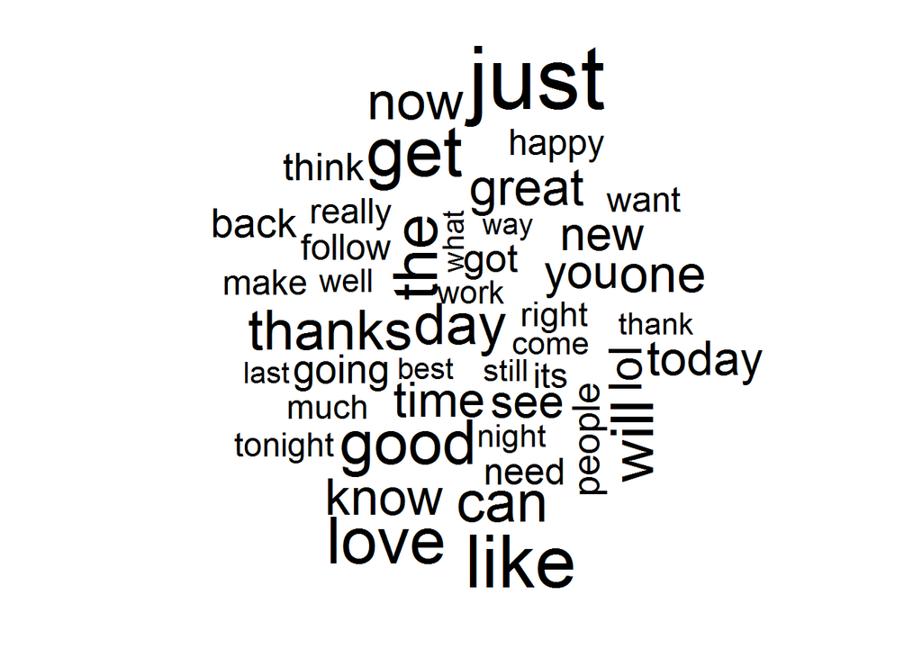

```r
TwitterText<-DocumentTermMatrix(VCorpus(VectorSource(Twitter[[1]]$content)))
TwitterTextNonSparse<-removeSparseTerms(TwitterText,0.99)
TwitterFreq<-sort(colSums(as.matrix(TwitterTextNonSparse)))
set.seed(1000)
wordcloud(names(TwitterFreq),TwitterFreq,min.freq = 3500)
```

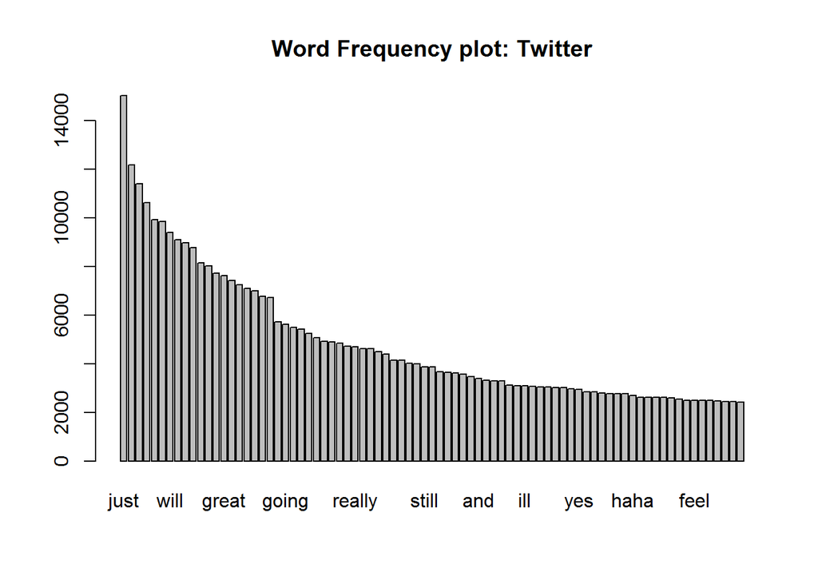

```r
barplot(height = sort(TwitterFreq,decreasing = TRUE),main = "Word Frequency plot: Twitter")
```

```r
head(sort(TwitterFreq,decreasing = TRUE),10)
```

```
##   just   like    get   love   good    the   will    day    can thanks
##  15033  12181  11391  10616   9930   9853   9398   9092   8971   8781
```

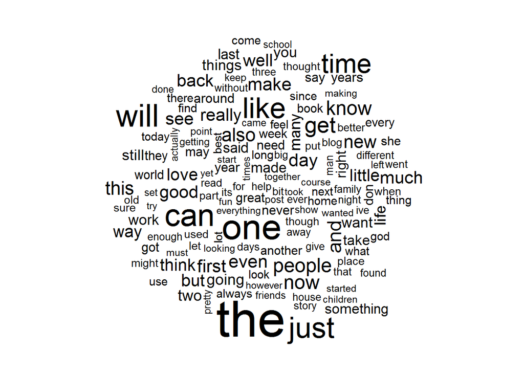

```r
BlogText<-DocumentTermMatrix(VCorpus(VectorSource(Twitter[[2]]$content)))
BlogTextNonSparse<-removeSparseTerms(BlogText,0.99)
BlogFreq<-sort(colSums(as.matrix(BlogTextNonSparse)))
set.seed(1000)
wordcloud(names(BlogFreq),BlogFreq,min.freq = 1500)
```

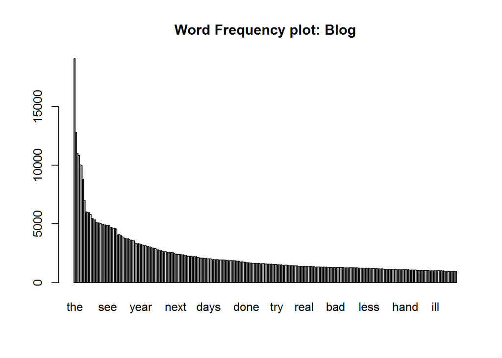

```r
barplot(height = sort(BlogFreq,decreasing = TRUE),main = "Word Frequency plot: Blog")
```

```r
head(sort(BlogFreq,decreasing = TRUE),10)
```

```
##    the    one   will    can   just   like   time    get   know people
##  19106  12802  11011  10849  10030   9969   8840   7005   6041   6004
```

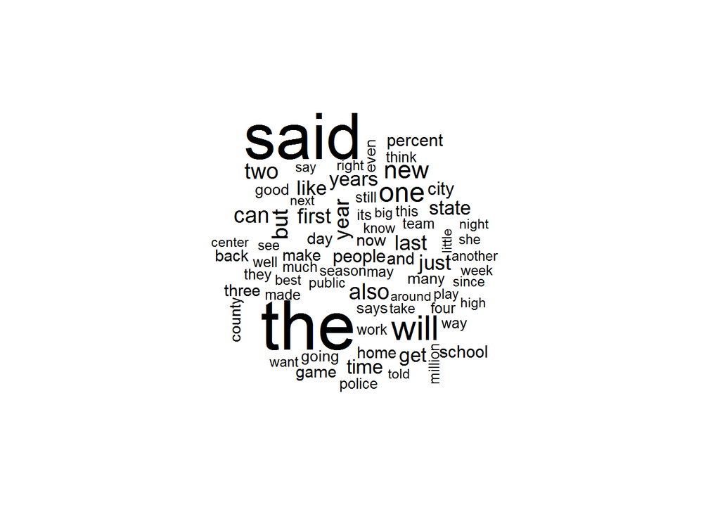

```r
NewsText<-DocumentTermMatrix(VCorpus(VectorSource(Twitter[[3]]$content)))
NewsTextNonSparse<-removeSparseTerms(NewsText,0.99)
NewsFreq<-sort(colSums(as.matrix(NewsTextNonSparse)))
set.seed(1000)
wordcloud(names(NewsFreq),NewsFreq,min.freq = 150)
```

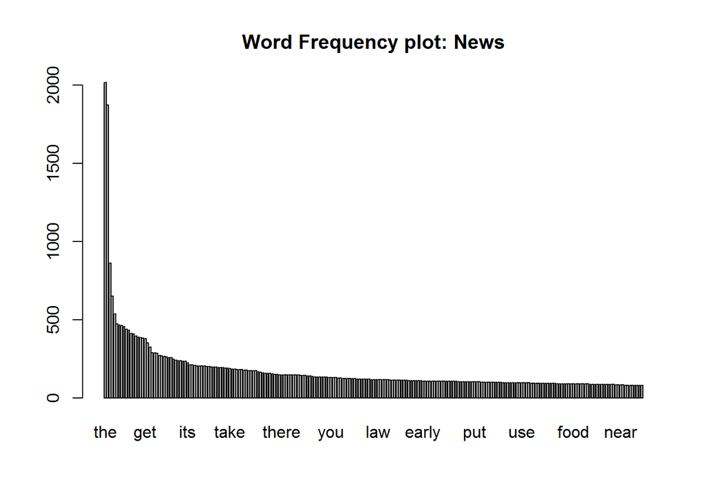

```r
barplot(height = sort(NewsFreq,decreasing = TRUE),main = "Word Frequency plot: News")
```

```r
head(sort(NewsFreq,decreasing = TRUE),10)
```

```
##  the said will  one  new  two also  can  but just
## 2018 1873  862  652  538  473  465  463  455  438
```

## Conclusion and Next steps

Finally, post the analysis we have a good grasp of the tools for text mining and the dataset is now in a form that can be used for developing the predictive model.

Next steps are:

1. Develop the predictive model
2. Develop the Shiny app
3. Deploy the Shiny app

## Reference

1. https://rpubs.com/diegolopezpozueta/40108
2. http://www.statmethods.net/graphs/bar.html
3. https://www.google.co.in/url?sa=t&rct=j&q=&esrc=s&source=web&cd=1&cad=rja&uact=8&ved=0ahUKEwic_pCN-IzUAhVKO48KHbfsB50QFggnMAA&url=https%3A%2F%2Fcran.r-project.org%2Fweb%2Fpackages%2Ftm%2Fvignettes%2Ftm.pdf&usg=AFQjCNFRvdLjHlL-Ne-1gS2epKqAh1Zppw&sig2=SI9VRE3lf41DBo8K4Mz4Gg
4. http://www.bannedwordlist.com/lists/swearWords.txt
5. http://www.frontgatemedia.com/a-list-of-723-bad-words-to-blacklist-and-how-to-use-facebooks-moderation-tool/
6. https://stat.ethz.ch/R-manual/R-devel/library/base/html/regex.html